# Выявление закономерностей, определяющих успешность компьютерных игр для интернет-магазина.

Интернет-магазин «Стримчик» продаёт по всему миру компьютерные игры. Из открытых источников доступны исторические данные о продажах игр, оценки пользователей и экспертов, жанры и платформы (например, Xbox или PlayStation). Нужно выявить определяющие успешность игры закономерности. Это позволит сделать ставку на потенциально популярный продукт и спланировать рекламные кампании. В датасете данные до 2016 года. Сейчас декабрь 2016 г., нужно спланировать кампанию на 2017-й. Нужно отработать принцип работы с данными. В наборе данных попадается аббревиатура ESRB (Entertainment Software Rating Board) — это ассоциация, определяющая возрастной рейтинг компьютерных игр. ESRB оценивает игровой контент и присваивает ему подходящую возрастную категорию, например, «Для взрослых», «Для детей младшего возраста» или «Для подростков».

**Описание данных**

- Name — название игры
- Platform — платформа
- Year_of_Release — год выпуска
- Genre — жанр игры
- NA_sales — продажи в Северной Америке (миллионы проданных копий)
- EU_sales — продажи в Европе (миллионы проданных копий)
- JP_sales — продажи в Японии (миллионы проданных копий)
- Other_sales — продажи в других странах (миллионы проданных копий)
- Critic_Score — оценка критиков (максимум 100)
- User_Score — оценка пользователей (максимум 10)
- Rating — рейтинг от организации ESRB (англ. Entertainment Software Rating Board). Эта ассоциация определяет рейтинг компьютерных игр и присваивает им подходящую возрастную категорию.

Данные за 2016 год могут быть неполными.

## Изучение данных из файла

```python
# Импорт библиотек
import pandas as pd
import numpy as np
from scipy import stats as st
import matplotlib.pyplot as plt
```

```python
# Чтение файла с данными
df = pd.read_csv('/datasets/games.csv')
```

```python
# Вывод общей информации о данных
df.info()
```

```
<class 'pandas.core.frame.DataFrame'>
RangeIndex: 16715 entries, 0 to 16714
Data columns (total 11 columns):
 #   Column           Non-Null Count  Dtype
---  ------           --------------  -----
 0   Name             16713 non-null  object
 1   Platform         16715 non-null  object
 2   Year_of_Release  16446 non-null  float64
 3   Genre            16713 non-null  object
 4   NA_sales         16715 non-null  float64
 5   EU_sales         16715 non-null  float64
 6   JP_sales         16715 non-null  float64
 7   Other_sales      16715 non-null  float64
 8   Critic_Score     8137 non-null   float64
 9   User_Score       10014 non-null  object
 10  Rating           9949 non-null   object
dtypes: float64(6), object(5)
memory usage: 1.4+ MB
```

```python
# Вывод первых 10 строк таблицы
df.head(10)
```

|  | Name | Platform | Year_of_Release | Genre | NA_sales | EU_sales | JP_sales | Other_sales | Critic_Score | User_Score | Rating |
| --- | --- | --- | --- | --- | --- | --- | --- | --- | --- | --- | --- |
| 0 | Wii Sports | Wii | 2006.0 | Sports | 41.36 | 28.96 | 3.77 | 8.45 | 76.0 | 8 | E |
| 1 | Super Mario Bros. | NES | 1985.0 | Platform | 29.08 | 3.58 | 6.81 | 0.77 | NaN | NaN | NaN |
| 2 | Mario Kart Wii | Wii | 2008.0 | Racing | 15.68 | 12.76 | 3.79 | 3.29 | 82.0 | 8.3 | E |
| 3 | Wii Sports Resort | Wii | 2009.0 | Sports | 15.61 | 10.93 | 3.28 | 2.95 | 80.0 | 8 | E |
| 4 | Pokemon Red/Pokemon Blue | GB | 1996.0 | Role-Playing | 11.27 | 8.89 | 10.22 | 1.00 | NaN | NaN | NaN |
| 5 | Tetris | GB | 1989.0 | Puzzle | 23.20 | 2.26 | 4.22 | 0.58 | NaN | NaN | NaN |
| 6 | New Super Mario Bros. | DS | 2006.0 | Platform | 11.28 | 9.14 | 6.50 | 2.88 | 89.0 | 8.5 | E |
| 7 | Wii Play | Wii | 2006.0 | Misc | 13.96 | 9.18 | 2.93 | 2.84 | 58.0 | 6.6 | E |
| 8 | New Super Mario Bros. Wii | Wii | 2009.0 | Platform | 14.44 | 6.94 | 4.70 | 2.24 | 87.0 | 8.4 | E |
| 9 | Duck Hunt | NES | 1984.0 | Shooter | 26.93 | 0.63 | 0.28 | 0.47 | NaN | NaN | NaN |

Посмотрим за какой период данные в датасете и объем данных для разных лет.

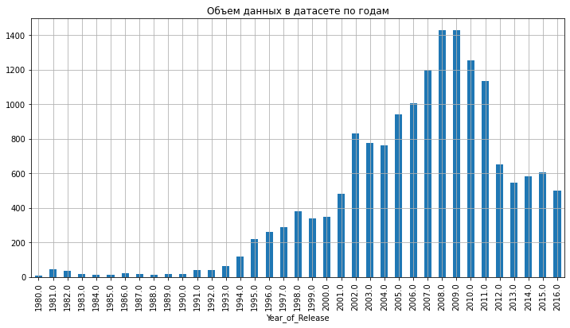

```python
# Столбчатая диаграмма на основе сводной таблицы
df.pivot_table(index='Year_of_Release', values='Platform', aggfunc='count').plot( kind='bar', figsize=(12, 6), grid=True,
                                title='Объем данных в датасете по годам', legend=False);
```

Выведем гистограммы для непрерывных числовых данных. (У столбца User_Score неправильный тип данных.)

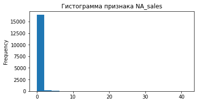

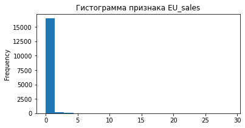

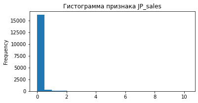

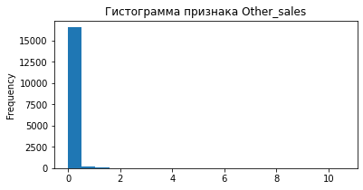

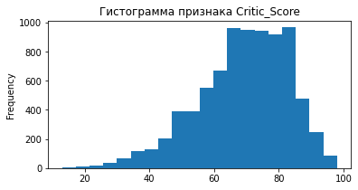

```python
# Гистограммы
for item in ['NA_sales', 'EU_sales', 'JP_sales', 'Other_sales', 'Critic_Score']:
    df[item].plot(y=item, kind='hist', title = 'Гистограмма признака '+item , bins=20, figsize=(6, 3))
    plt.show()
```

### Выводы

Итак, в таблице games 11 столбцов. Типы данных в таблице float64, object.

Количество значений в столбцах различается. Значит, в данных есть пропущенные значения.

В столбце Year_of_Release тип данных float64, хотя это год выпуска игры. Здесь достаточно int32.

В столбце User_Score тип данных object, хотя это оценка пользователей - количественная перемення. Здесь должен быть тип данных float64.

За период с 2002 по 2011 год в датасете данных больше, чем за другие периоды.

В гистограммах продаж по Северной Америке и Европе есть "хвосты".

## Подготовка данных

Приведем названия столбцов к нижнему регистру

```python
# Приведение значений Series к нижнему регистру
df.columns = df.columns.str.lower()
df.info()
```

```
<class 'pandas.core.frame.DataFrame'>
RangeIndex: 16715 entries, 0 to 16714
Data columns (total 11 columns):
 #   Column           Non-Null Count  Dtype
---  ------           --------------  -----
 0   name             16713 non-null  object
 1   platform         16715 non-null  object
 2   year_of_release  16446 non-null  float64
 3   genre            16713 non-null  object
 4   na_sales         16715 non-null  float64
 5   eu_sales         16715 non-null  float64
 6   jp_sales         16715 non-null  float64
 7   other_sales      16715 non-null  float64
 8   critic_score     8137 non-null   float64
 9   user_score       10014 non-null  object
 10  rating           9949 non-null   object
dtypes: float64(6), object(5)
memory usage: 1.4+ MB
```

Приведем столбец с годом выпуска игры к типу int32, так как год - целочисленное значение. Предварительно удалим все строки из датасета, где год выпуска отсутствует. Мы не можем заполнить эти данные произвольным значением, и их не очень много:

```python
# Подсчет пропущенных значений, округление до одного знака после запятой
print('Пропущено данных в столбце с годом выпуска игры: {} %'.format(round(df['year_of_release'].isna().sum()/df.shape[0]*100, 1)))
print('Всего строк в датасете: {}'.format(df.shape[0]))
print('Количество строк с пропусками: {}'.format(df['year_of_release'].isna().sum()))
```

```
Пропущено данных в столбце с годом выпуска игры: 1.6 %
Всего строк в датасете: 16715
Количество строк с пропусками: 269
```

```python
# Удаление строк, переиндексация
df = df.dropna(subset =[ 'year_of_release'])
df.reset_index(drop=True);
```

Проверим что пропущенных значений в столбце года выпуска нет, и лишних строк не удалено.

```python
# Подсчет пропущенных значений
print('Всего строк в датасете: {}'.format(df.shape[0]))
print('Количество строк с пропусками: {}'.format(df['year_of_release'].isna().sum()))
```

```
Всего строк в датасете: 16446
Количество строк с пропусками: 0
```

```python
# Приведение к типу int32
df['year_of_release'] = df['year_of_release'].astype('int32')
```

Приведем столбец с оценками пользователей к типу float64 так как это количественные данные и число может содержать дробную часть. В этом столбце встречается аббревиатура 'tbd'. Она означает что рейтинг еще неизвестен. Заменим ее на значения NaN, для этого используем параметр errors='coerce'.

```python
# Приведение к типу float64
df['user_score'] = pd.to_numeric(df['user_score'], errors='coerce');
```

Проверим сколько пропущено данных в других столбцах:

```python
# Подсчет пропущенных значений, округление до одного знака после запятой
print('Пропущено данных в столбце с оценками пользователей: {}% ({} строк)'.
      format(round(df['user_score'].isna().mean()*100, 1), df['user_score'].isna().sum()))
print('Пропущено данных в столбце с оценками критиков: {}% ({} строк)'.
      format(round(df['critic_score'].isna().mean()*100, 1), df['critic_score'].isna().sum()))
print('Пропущено данных в столбце с рейтингом: {}% ({} строк)'.
      format(round(df['rating'].isna().mean()*100, 1), df['rating'].isna().sum()))
```

```
Пропущено данных в столбце с оценками пользователей: 54.6% (8983 строк)
Пропущено данных в столбце с оценками критиков: 51.5% (8463 строк)
Пропущено данных в столбце с рейтингом: 40.6% (6678 строк)
```

Попробуем посмотреть, насколько неравномерно данные об оценках не заполнены по годам. Для этого добавим столбцы со значениями-флагами: есть ли оценка. Затем выведем столбчатые диаграммы, показывающие среднее количество оценок по годам. Зададим диапазон оси y от 0 до 1, это позволит наглядно показать какая часть данных с оценками.

```python
# Добавление столбцов на основании других столбцов
df['user_score_isna'] = ~df['user_score'].isna()
df['critic_score_isna'] = ~df['critic_score'].isna()
df['rating_isna'] = ~df['rating'].isna()
```

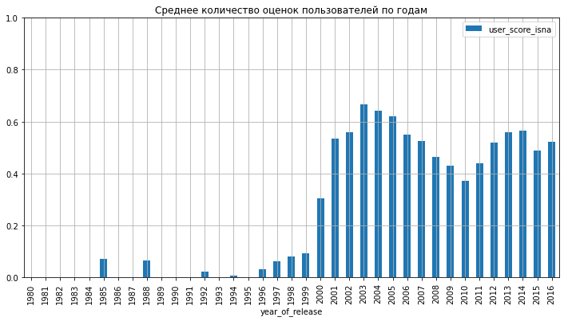

```python
# Столбчатая диаграмма на основе сводной таблицы
df.pivot_table(index = ['year_of_release'], values='user_score_isna', aggfunc='mean').plot(y='user_score_isna', ylim=(0, 1),
                    kind='bar', figsize=(12, 6), grid=True, title='Среднее количество оценок пользователей по годам');
```

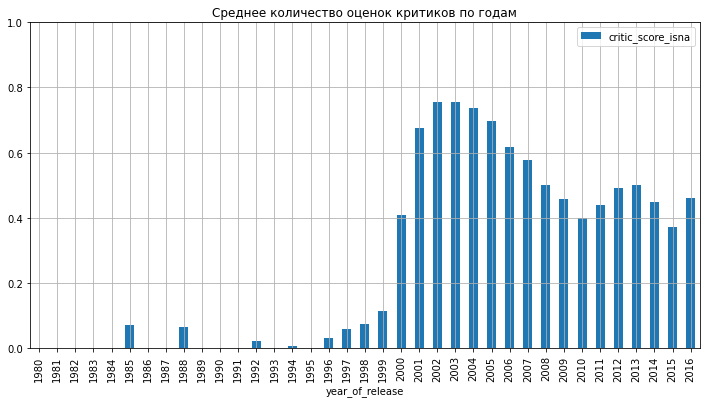

```python
# Столбчатая диаграмма на основе сводной таблицы
df.pivot_table(index = ['year_of_release'], values='critic_score_isna', aggfunc='mean').plot(y='critic_score_isna',
                kind='bar', figsize=(12, 6), grid=True, ylim=(0, 1), title='Среднее количество оценок критиков по годам');
```

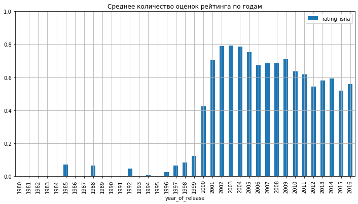

```python
# Столбчатая диаграмма на основе сводной таблицы
df.pivot_table(index = ['year_of_release'], values='rating_isna', aggfunc='mean').plot(y='rating_isna', kind='bar',
                    figsize=(12, 6), ylim=(0, 1), grid=True, title='Среднее количество оценок рейтинга по годам');
```

Посмотрим, насколько неравномерно данные об оценках не заполнены по платформам. Так же выведем столбчатые диаграммы.

```python
df_recent = df.query('year_of_release>=2000')
```

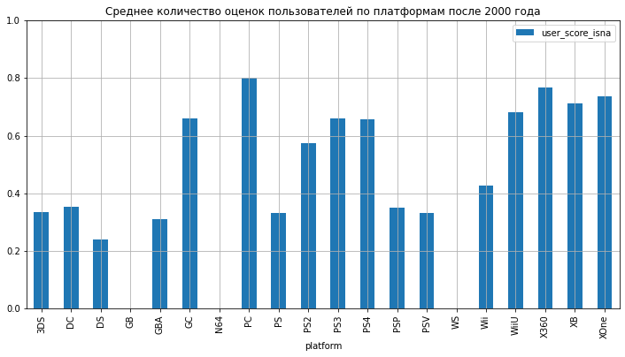

```python
# Столбчатая диаграмма на основе сводной таблицы
df_recent.pivot_table(index = ['platform'], values='user_score_isna', aggfunc='mean').plot(y='user_score_isna', ylim=(0, 1),
    kind='bar', figsize=(12, 6), grid=True, title='Среднее количество оценок пользователей по платформам после 2000 года');
```

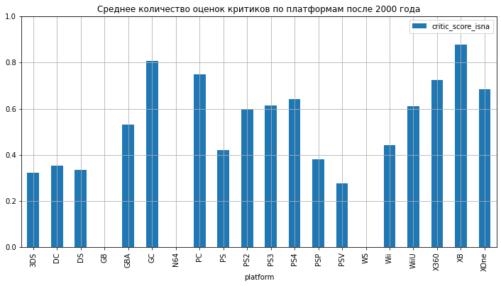

```python
# Столбчатая диаграмма на основе сводной таблицы
df_recent.pivot_table(index=['platform'], values='critic_score_isna', aggfunc='mean').plot(y='critic_score_isna', kind='bar',
    figsize=(12, 6), grid=True, ylim=(0, 1), title='Среднее количество оценок критиков по платформам после 2000 года');
```

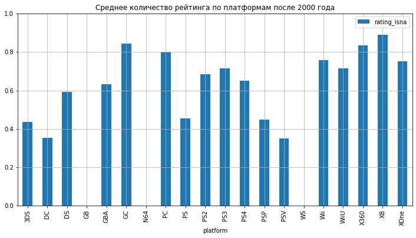

```python
# Столбчатая диаграмма на основе сводной таблицы
df_recent.pivot_table(index=['platform'], values='rating_isna', aggfunc='mean').plot( y='rating_isna', kind='bar',
            figsize=(12, 6), ylim=(0, 1), grid=True, title='Среднее количество рейтинга по платформам после 2000 года');
```

Видно, что для нескольких платформ оценки и рейтинг отсутствуют. Возможно это не популярные или устаревшие платформы, количество пользователей на них маленькое, поэтому нет оценок.

Удалим добавленные для подсчета пропусков столбцы

```python
# удаление столбцов с вспомогательными данными
df = df.drop(columns='user_score_isna')
df = df.drop(columns='critic_score_isna')
df = df.drop(columns='rating_isna')
```

Посмотрим сколько игр оценено в датасете и сколько примерно записей по одной игре.

```python
# Количество уникальных значений
len(df['name'].unique())
```

```
11427
```

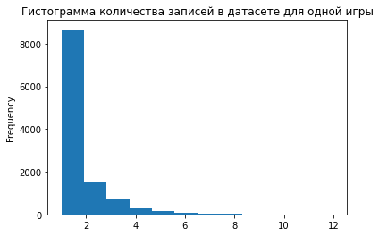

```python
# Частота записей по одному признаку
df['name'].value_counts().plot(kind='hist', bins=12, title='Гистограмма количества записей в датасете для одной игры');
```

Количество записей на одну игру в большинстве случаев будет равно 1. Заполнение оценок медианными значениями по игре в таком случае не подходит.

В данных есть строки с отсутствующим названием игры. Посмотрим на них.

```python
df.query('name.isna()')
```

|  | name | platform | year_of_release | genre | na_sales | eu_sales | jp_sales | other_sales | critic_score | user_score | rating |
| --- | --- | --- | --- | --- | --- | --- | --- | --- | --- | --- | --- |
| 659 | NaN | GEN | 1993 | NaN | 1.78 | 0.53 | 0.00 | 0.08 | NaN | NaN | NaN |
| 14244 | NaN | GEN | 1993 | NaN | 0.00 | 0.00 | 0.03 | 0.00 | NaN | NaN | NaN |

Это 2 строки, в которых отсутствует большинство данных. Скорее всего они попали в датасет по ошибке. Можно их удалить.

```python
# Удаление строк, переиндексация
df = df.dropna(subset =['name'])
df.reset_index(drop=True);
```

```python
# Количество полных дубликатов
df.duplicated().sum()
```

```
0
```

Полных дубликатов в данных нет. Ищем неполные дубликаты по сочетанию признаков год, платформа, наименование игры:

```python
# Дубликаты по сочетанию трех значений
df[df[['name','platform','year_of_release']].duplicated()]
```

|  | name | platform | year_of_release | genre | na_sales | eu_sales | jp_sales | other_sales | critic_score | user_score | rating |
| --- | --- | --- | --- | --- | --- | --- | --- | --- | --- | --- | --- |
| 16230 | Madden NFL 13 | PS3 | 2012 | Sports | 0.0 | 0.01 | 0.0 | 0.0 | 83.0 | 5.5 | E |

```python
# Срез
df.query('name == "Madden NFL 13" and platform=="PS3"')
```

|  | name | platform | year_of_release | genre | na_sales | eu_sales | jp_sales | other_sales | critic_score | user_score | rating |
| --- | --- | --- | --- | --- | --- | --- | --- | --- | --- | --- | --- |
| 604 | Madden NFL 13 | PS3 | 2012 | Sports | 2.11 | 0.22 | 0.0 | 0.23 | 83.0 | 5.5 | E |
| 16230 | Madden NFL 13 | PS3 | 2012 | Sports | 0.00 | 0.01 | 0.0 | 0.00 | 83.0 | 5.5 | E |

Удалим строку с индексом 16230, так как похоже что это ошибочные данные, в них почти нет продаж.

```python
# Удаление строки по индексу
df = df.drop(index=[16230])
df.reset_index(drop=True);
```

Поставим значения-заглушки для пропущенных значений:

```python
# Добавление столбцов на основании других столбцов
df['user_score'] = df['user_score'].fillna(-1)
df['critic_score'] = df['critic_score'].fillna(-1)
```

Посчитаем суммарные продажи во всех регионах и запишем в отдельный столбец.

```python
# Создание столбца на основании других столбцов
df['total_sales'] = df['na_sales']+df['eu_sales']+df['jp_sales']+df['other_sales']
```

#### Выводы

Были внесены следующие изменения в данные:

- названия столбцов приведены к нижнему регистру
- столбец с годом выпуска игры приведен к типу int32
- столбец с оценками пользователей приведен к типу float64
- Удалено 2 строки с отсутствующими полями name и genre
- Удалена 1 стрка - неполный дубликат
- Установлены значения-заглушки для пропущенных значений в столбцах оценки пользователей и оценки критиков, так как не получится заменить их медианными значениями по игре из-за маленького количества данных на одну игру.
- Посчитаны суммарные продажи во всех регионах и записаны в отдельный столбец.

## Исследовательский анализ данных

### Количество выпущенных игр по годам

Посмотрим сколько игр выпускалось в разные годы. Для этого выберем все сочетания значений год выпуска + наименование игры без дубликатов.

```python
# Создание новой таблицы на основе среза, удаление дублей.
df_game_year = df[['year_of_release', 'name']]
df_game_year = df_game_year.drop_duplicates()
```

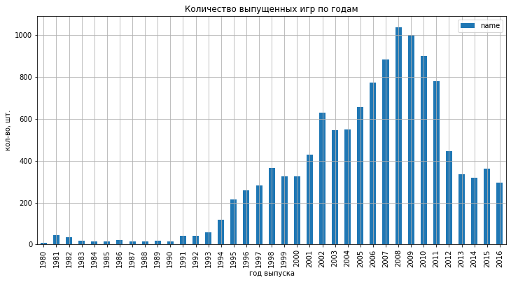

```python
# Столбчатая диаграмма на основе сводной таблицы
df_game_year.pivot_table(index = ['year_of_release'], values='name', aggfunc='count').plot(y='name', kind='bar',
                            xlabel='год выпуска', ylabel='кол-во, шт.',
                            figsize=(12, 6), grid=True, title='Количество выпущенных игр по годам');
```

#### Вывод

До 1994 года выпускалось до 100 игр в год, за этот период данные точно не важны. В периоде с 1995 по 2008 год количество выпускаемых игр увеличивалось почти каждый год и в 2008-м достигло максимума - более 1000 игр в год. Затем количество выпускаемых игр начало снижаться, особенно резко спад произошел в 2012 году. С 2013 по 2016 год держится примерно одинаковое количество выпускаемых игр - от 300 до 400 игр в год, этот период скорее всего является самым важным для исследования.

### Продажи по платформам

Посмотрим, как менялись продажи по платформам. Выберем платформы с наибольшими суммарными продажами.

```python
# Рейтинг TOP-18 по сумме значений.
platform_list = df.groupby('platform')['total_sales'].sum().sort_values(ascending=False).head(18)
display(platform_list)
```

```
platform
PS2     1233.56
X360     961.24
PS3      931.33
Wii      891.18
DS       802.78
PS       727.58
PS4      314.14
GBA      312.88
PSP      289.53
3DS      257.81
PC       255.76
GB       254.43
XB       251.57
NES      251.05
N64      218.01
SNES     200.04
GC       196.73
XOne     159.32
Name: total_sales, dtype: float64
```

Построим распределение продаж игр (миллионы проданных копий) для каждой платформы по годам за весь период датасета.

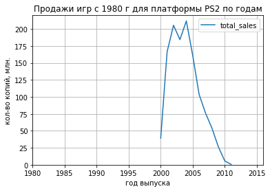

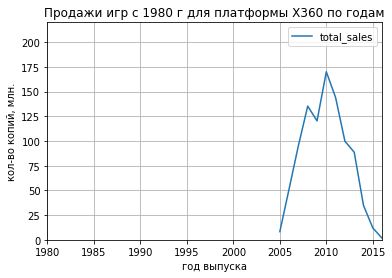

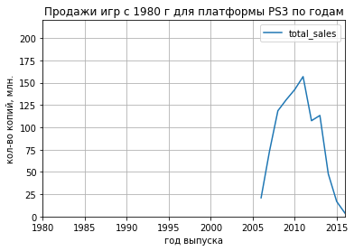

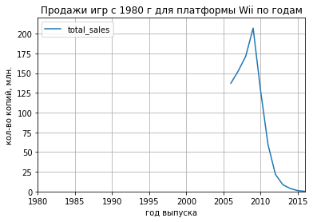

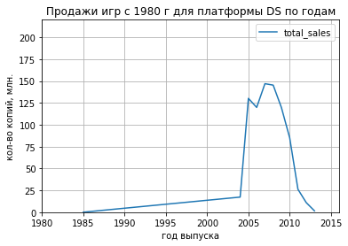

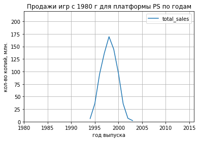

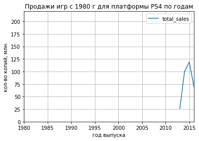

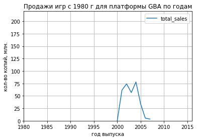

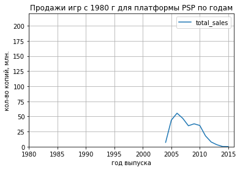

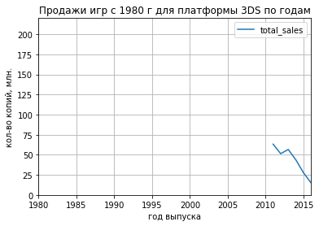

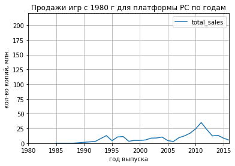

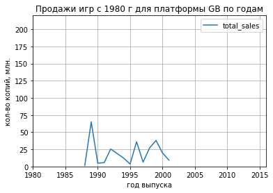

[6 more figures not shown]

```python
# Вывод графиков в цикле
for platf in platform_list.index:
    df.query('platform == @platf').pivot_table(index='year_of_release', values='total_sales',
                aggfunc='sum').plot(xlim = (1980, 2016), ylim=(0, 220), xlabel='год выпуска', ylabel='кол-во копий, млн.',
                title='Продажи игр с 1980 г для платформы '+platf+ " по годам", grid=True)
```